# *Regression: Supervised Machine Learning*

### *What is Regression?*

_Regression is a method of modelling a target value based on independent predictors. It is a statistical tool which is used to find out the relationship between the outcome variable also known as the *dependent variable*, and one or more variable often called as *independent variables*._

### *When and why do you use Regression?*

*Regression is performed when the dependent variable is of continuous data type and Predictors or independent variables could be of any data type like continuous, nominal/categorical etc. Regression method tries to find the best fit line which shows the relationship between the dependent variable and predictors with least error.*

*In regression, the output/dependent variable is the function of an independent variable and the coefficient and the error term.*

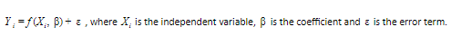

# *Linear Regression*

### *What is Linear Regression?*

*Linear Regression is the basic form of regression analysis. It assumes that there is a linear relationship between the dependent variable and the predictor(s). In regression, we try to calculate the best fit line which describes the relationship between the predictors and predictive/dependent variable.*

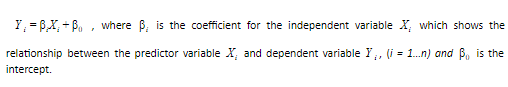

### *What is Linearity?*

*The term "linearity" in algebra refers to a linear relationship between two or more variables. If we draw this relationship in a two dimensional space (between two variables, in this case), we get a straight line.*

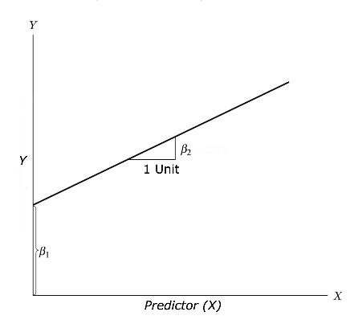

*We know that the equation of a straight line is basically:*

```
y = mx + b
```

_Where b is the *intercept* and m is the *slope* of the line. So basically, the linear regression algorithm gives us the most optimal value for the intercept and the slope (in two dimensions). The y and x variables remain the same, since they are the data features and cannot be changed. The values that we can control are the intercept and slope. There can be multiple straight lines depending upon the values of intercept and slope. Basically what the linear regression algorithm does is it fits multiple lines on the data points and returns the line that results in the least error._

### *Assumptions of Linear Regression*

*There are few assumptions associated with a linear regression model:*

*1. Linearity:* *There should be a linear relationship between dependent and independent variables like shown in the below example graph.*

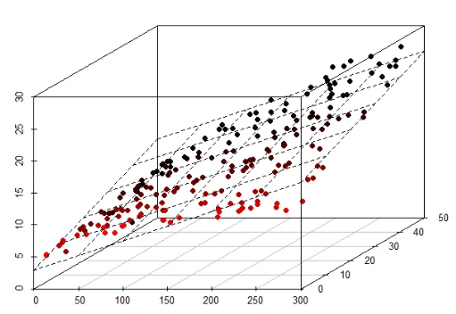

*2. Multicollinearity:* _There should not be high correlation between two or more independent variables. Multicollinearity can be checked using *correlation matrix, Variance Influencing Factor (VIF)*._

*How to identify Multicollinearity:*

*Here are 6 indicators of multicollinearity.*

*1. Very high standard errors for regression coefficients*

*When standard errors are orders of magnitude higher than their coefficients, that’s an indicator.*

*2. The overall model is significant, but none of the coefficients are*

*Remember that a p-value for a coefficient tests whether the unique effect of that predictor on Y is zero. If all predictors overlap in what they measure, there is little unique effect, even if the predictors as a group have an effect on Y.*

*3. Large changes in coefficients when adding predictors*

*If the predictors are completely independent of each other, their coefficients won’t change at all when you add or remove one. But the more they overlap, the more drastically their coefficients will change.*

*4. Coefficients have signs opposite what you’d expect from theory*

*Be careful here as you don’t want to disregard an unexpected finding as problematic. Not all effects opposite theory indicate a problem with the model. That said, it could be multicollinearity and warrants taking a second look at other indicators.*

*5. Coefficients on different samples are wildly different*

*If you have a large enough sample, split the sample in half and run the model separately on each half. Wildly different coefficients in the two models could be a sign of multicollinearity.*

*6. High Variance Inflation Factor (VIF) and Low Tolerance*

*These two useful statistics are reciprocals of each other. So either a high VIF or a low tolerance is indicative of multicollinearity. VIF is a direct measure of how much the variance of the coefficient (ie. its standard error) is being inflated due to multicollinearity.*

*How to resolve Multicollinearity problem:*

- *Remove some of the highly correlated independent variables.*
- *Linearly combine the independent variables, such as adding them together.*
- *Perform an analysis designed for highly correlated variables, such as principal components analysis or partial least squares regression.*

*3. Homoscedasticity:* *If Variance of errors are constant across independent variables, then it is called Homoscedasticity. The residuals should be homoscedastic. Standardized residuals versus predicted values is used to check homoscedasticity as shown in the below figure. **Breusch-Pagan** and **White** tests are the famous tests used to check Homoscedasticity. **Q-Q plots** are also used to check homoscedasticity.*

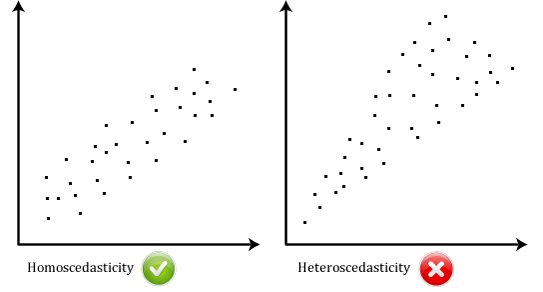

*Possible reasons of arising Heteroscedasticity:*

- *Often occurs in those data sets which have a large range between the largest and the smallest observed values i.e. when there are outliers.*
- *When model is not correctly specified.*
- *If observations are mixed with different measures of scale.*
- *When incorrect transformation of data is used to perform the regression.*
- *Skewness in the distribution of a regressor, and may be some other sources.*

*Statistical Testing:*

- *Breush – Pegan Test:* *It tests whether the variance of the errors from regression is dependent on the values of the independent variables. In that case, heteroskedasticity is present.*
- *White test:* *White test establishes whether the variance of the errors in a regression model is constant.*

*How to solve Hetroscedasticity problem:*

- *Re-build the model with new predictors.*
- *Variable transformation such as Box-Cox transformation.*

*4. Multivariate Normality:* *Residuals should be normally distributed.*

*5. Categorical Data:* *Any categorical data present should be converted into dummy variables.*

*6. Minimum records:* *There should be at least 20 records of independent variables.*

### *Odinary Least Square*

*When implementing linear regression of some dependent variable 𝑦 on the set of independent variables 𝐱 = (𝑥₁, …, 𝑥ᵣ), where 𝑟 is the number of predictors, you assume a linear relationship between 𝑦 and 𝐱: 𝑦 = 𝛽₀ + 𝛽₁𝑥₁ + ⋯ + 𝛽ᵣ𝑥ᵣ + 𝜀. This equation is the regression equation. 𝛽₀, 𝛽₁, …, 𝛽ᵣ are the regression coefficients, and 𝜀 is the random error.*

*Linear regression calculates the estimators of the regression coefficients or simply the predicted weights, denoted with 𝑏₀, 𝑏₁, …, 𝑏ᵣ. They define the estimated regression function 𝑓(𝐱) = 𝑏₀ + 𝑏₁𝑥₁ + ⋯ + 𝑏ᵣ𝑥ᵣ. This function should capture the dependencies between the inputs and output sufficiently well.*

_The estimated or predicted response, 𝑓(𝐱ᵢ), for each observation 𝑖 = 1, …, 𝑛, should be as close as possible to the corresponding actual response 𝑦ᵢ. The differences 𝑦ᵢ - 𝑓(𝐱ᵢ) for all observations 𝑖 = 1, …, 𝑛, are called the *residuals*. Regression is about determining the best predicted weights, that is the weights corresponding to the smallest residuals. The line from this regression equation passes near/through all the data points & is the best approximation of the given set of data, such line is called as *Line of Best Fit*._

_To get the best weights, you usually minimize the sum of squared residuals (SSR) for all observations 𝑖 = 1, …, 𝑛: SSR = Σᵢ(𝑦ᵢ - 𝑓(𝐱ᵢ))². This approach is called the method of *ordinary least squares*. Therefore Linear regression is also callsed as *OLS regression*._

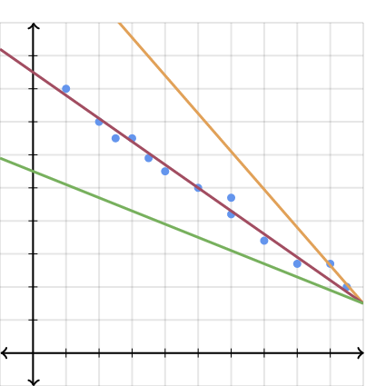

### *Cost Function*

*MSE measures the average squared difference between an observation’s actual and predicted values. The output is a single number representing the cost, or score, associated with our current set of weights. Our goal is to minimize MSE to improve the accuracy of our model.*

*Given our simple linear equation y=mx+b, we can calculate MSE as:*

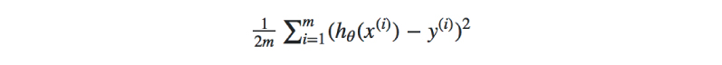

### *Gradient Descent*

*To minimize MSE we use Gradient Descent to calculate the gradient of our cost function.*

*There are two parameters (coefficients) in our cost function we can control: weight m and bias b. Since we need to consider the impact each one has on the final prediction, we use partial derivatives. To find the partial derivatives, we use the Chain rule.*

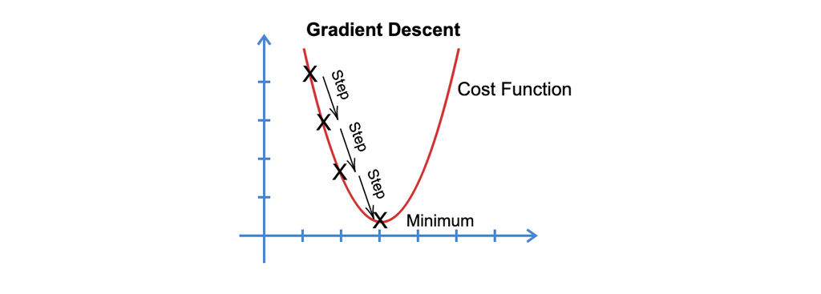

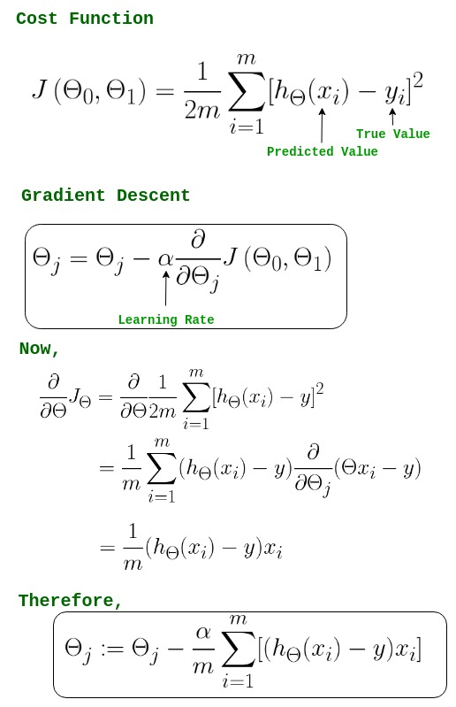

*where α, alpha, is the learning rate, or how rapidly do we want to move towards the minimum. We can always overshoot if the value of α is too large.*

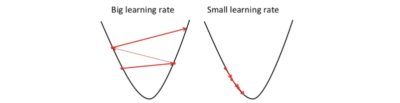

*Normalization/Standardization in Linear Regression:* _As the number of features grows, calculating gradient takes longer to compute. We can speed this up by “normalizing” our input data to ensure all values are within the same range. This is especially important for datasets with high standard deviations or differences in the ranges of the attributes. So we need to normalize our features so they are all in the range -1 to 1. [Feature Scaling](https://github.com/PIYUSHSINGLA/Data-Preprocessing/blob/master/4_Feature_Scaling.ipynb)_

### *Math for Linear Regression*

*To express the regression equation in matrix form, we need to define three matrices: Y, b, and X.*

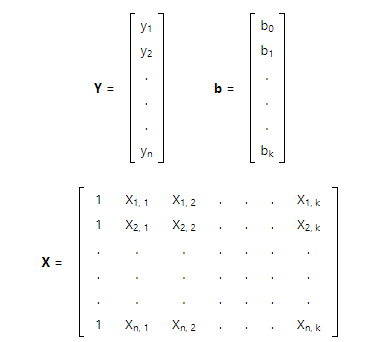

*Given these matrices, the multiple regression equation can be expressed concisely as:*

**Y = Xb**

*Normal Equations in Matrix Form*

*Just as the regression equation can be expressed compactly in matrix form, so can the normal equations. The least squares normal equations can be expressed as:*

**X'Y = X'Xb**

*Here, matrix X' is the transpose of matrix X. To solve for regression coefficients, simply pre-multiply by the inverse of X'X:*

**b = (X'X)-1X'Y**

*To solve this equation, we need to complete the following steps:*

- *Define X.*
- *Define X'.*
- *Compute X'X.*
- *Find the inverse of X'X.*
- *Define Y.*

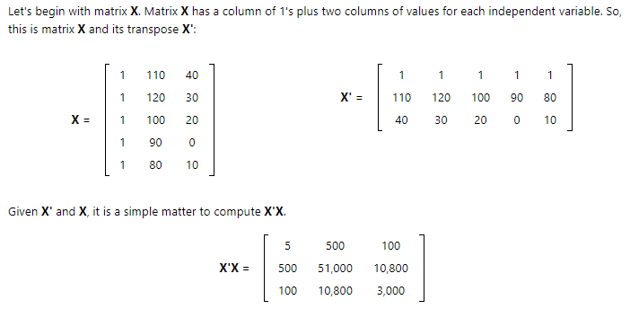

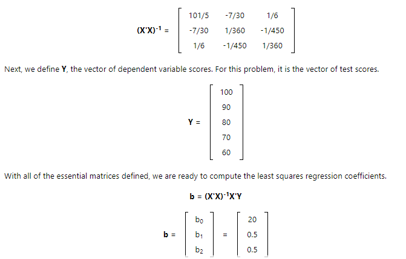

*[Find inverse of matrix](https://www.mathsisfun.com/algebra/matrix-inverse.html)*

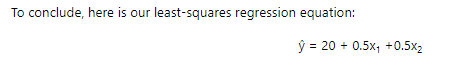

### *Graphical Analysis*

- *Scatter plot:* _Visualize the linear relationship between the predictor and response. [Scatter Plot](https://github.com/PIYUSHSINGLA/Python-Data-Science/blob/master/Learning_Seaborn.ipynb)_
- *Box plot:* *To spot any outlier observations in the variable. Having outliers in your predictor can drastically affect the predictions as they can easily affect the direction/slope of the line of best fit.* _[Outlier Detection](https://github.com/PIYUSHSINGLA/Data-Preprocessing/blob/master/3_Outliers.ipynb)_
- *Density plot:* _To see the distribution of the predictor variable. Ideally, a close to normal distribution (a bell shaped curve) [Normality Test](https://github.com/PIYUSHSINGLA/Statistics/blob/master/2.%20Descriptive%20Statistics/1_Descriptive_Statsitics.ipynb), without being skewed to the left or right is preferred. If not normal, then apply transformation techniques. [Transformations](https://github.com/PIYUSHSINGLA/Data-Preprocessing/blob/master/5_Variable_Transformation.ipynb)_

### *Correlation*

*Correlation is a statistical measure that suggests the level of linear dependence between two variables. Correlation can take values between -1 to +1. If we observe for every instance where speed increases, the distance also increases along with it, then there is a high positive correlation between them and therefore the correlation between them will be closer to 1. The opposite is true for an inverse relationship, in which case, the correlation between the variables will be close to -1.*

_A value closer to 0 suggests a weak relationship between the variables. A low correlation (-0.2 < x < 0.2) probably suggests that much of variation of the response variable (Y) is unexplained by the predictor (X), in which case, we should probably look for better explanatory variables. [Correlation](https://github.com/PIYUSHSINGLA/Statistics/blob/master/2.%20Descriptive%20Statistics/3_Descriptive_Statistics.ipynb)_

### *Categorical Predictor Variables*

_Categorical predictor variables cannot be entered directly into a regression model and be meaningfully interpreted, some other method of dealing are various Encodings like one-hot encoding, label encoding etc. [Encodings](https://github.com/PIYUSHSINGLA/Data-Preprocessing/blob/master/6_Categorical_Feature_Encoding.ipynb)_

```python
# Packages / libraries

import os #provides functions for interacting with the operating system

import numpy as np
import pandas as pd
from matplotlib import pyplot as plt
import seaborn as sns

%matplotlib inline

# To change scientific numbers to float
np.set_printoptions(formatter={'float_kind':'{:f}'.format})

# Increases the size of sns plots
sns.set(rc={'figure.figsize':(12,10)})

import warnings
warnings.filterwarnings('ignore')
```

## *What is Simple Linear Regression?*

*Simple linear regression is a statistical method that allows us to summarize and study relationships between two continuous (quantitative) variables:*

- *One variable, denoted x, is regarded as the **predictor, explanatory, independent variable or input, features**.*
- *The other variable, denoted y, is regarded as the **response, outcome, target or dependent variable**.*

*The simplest kind of linear regression involves taking a set of data (xi,yi), and trying to determine the "best" linear relationship*

```
y = a * x + b
```

*Data*

*We have downloaded a fuel consumption dataset, FuelConsumption.csv, which contains model-specific fuel consumption ratings and estimated carbon dioxide emissions for new light-duty vehicles for retail sale in Canada. [Dataset source](https://www.kaggle.com/sarita19/fuel-consumption)*

- *MODELYEAR e.g. 2014*
- *MAKE e.g. Acura*
- *MODEL e.g. ILX*
- *VEHICLE CLASS e.g. SUV*
- *ENGINE SIZE e.g. 4.7*
- *CYLINDERS e.g 6*
- *TRANSMISSION e.g. A6*
- *FUEL CONSUMPTION in CITY(L/100 km) e.g. 9.9*
- *FUEL CONSUMPTION in HWY (L/100 km) e.g. 8.9*
- *FUEL CONSUMPTION COMB (L/100 km) e.g. 9.2*
- *CO2 EMISSIONS (g/km) e.g. 182 --> low --> 0*

```python
# Reading dataset

data = pd.read_csv(r'C:\Users\PiyushSin\Downloads\FuelConsumption.csv')
data.head()
```

|  | MODELYEAR | MAKE | MODEL | VEHICLECLASS | ENGINESIZE | CYLINDERS | TRANSMISSION | FUELTYPE | FUELCONSUMPTION_CITY | FUELCONSUMPTION_HWY | FUELCONSUMPTION_COMB | FUELCONSUMPTION_COMB_MPG | CO2EMISSIONS |
| --- | --- | --- | --- | --- | --- | --- | --- | --- | --- | --- | --- | --- | --- |
| 0 | 2014 | ACURA | ILX | COMPACT | 2.0 | 4 | AS5 | Z | 9.9 | 6.7 | 8.5 | 33 | 196 |
| 1 | 2014 | ACURA | ILX | COMPACT | 2.4 | 4 | M6 | Z | 11.2 | 7.7 | 9.6 | 29 | 221 |
| 2 | 2014 | ACURA | ILX HYBRID | COMPACT | 1.5 | 4 | AV7 | Z | 6.0 | 5.8 | 5.9 | 48 | 136 |
| 3 | 2014 | ACURA | MDX 4WD | SUV - SMALL | 3.5 | 6 | AS6 | Z | 12.7 | 9.1 | 11.1 | 25 | 255 |
| 4 | 2014 | ACURA | RDX AWD | SUV - SMALL | 3.5 | 6 | AS6 | Z | 12.1 | 8.7 | 10.6 | 27 | 244 |

```python
data.info()
```

```
<class 'pandas.core.frame.DataFrame'>
RangeIndex: 1067 entries, 0 to 1066
Data columns (total 13 columns):
MODELYEAR                   1067 non-null int64
MAKE                        1067 non-null object
MODEL                       1067 non-null object
VEHICLECLASS                1067 non-null object
ENGINESIZE                  1067 non-null float64
CYLINDERS                   1067 non-null int64
TRANSMISSION                1067 non-null object
FUELTYPE                    1067 non-null object
FUELCONSUMPTION_CITY        1067 non-null float64
FUELCONSUMPTION_HWY         1067 non-null float64
FUELCONSUMPTION_COMB        1067 non-null float64
FUELCONSUMPTION_COMB_MPG    1067 non-null int64
CO2EMISSIONS                1067 non-null int64
dtypes: float64(4), int64(4), object(5)
memory usage: 108.5+ KB
```

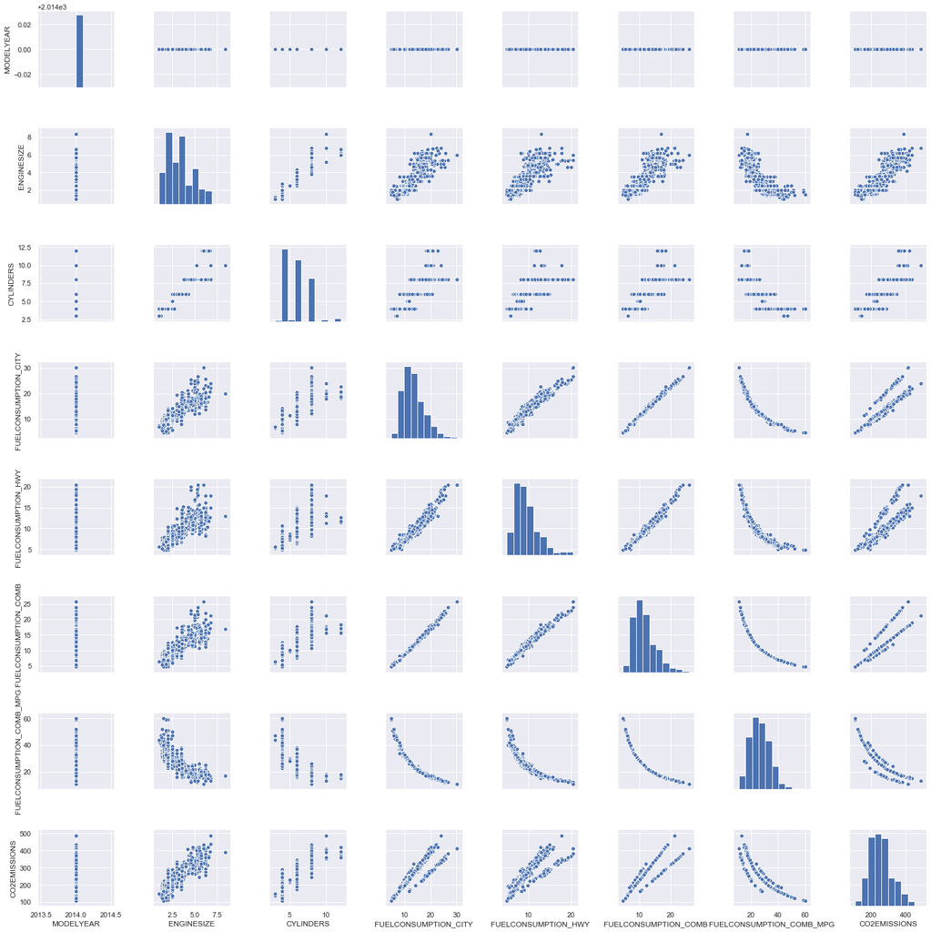

```python
sns.pairplot(data)
```

```python
data_new = data[[
    'ENGINESIZE', 'CYLINDERS', 'FUELCONSUMPTION_COMB', 'FUELCONSUMPTION_CITY',
    'FUELCONSUMPTION_HWY', 'CO2EMISSIONS'
]]
data_new.head()
```

|  | ENGINESIZE | CYLINDERS | FUELCONSUMPTION_COMB | FUELCONSUMPTION_CITY | FUELCONSUMPTION_HWY | CO2EMISSIONS |
| --- | --- | --- | --- | --- | --- | --- |
| 0 | 2.0 | 4 | 8.5 | 9.9 | 6.7 | 196 |
| 1 | 2.4 | 4 | 9.6 | 11.2 | 7.7 | 221 |
| 2 | 1.5 | 4 | 5.9 | 6.0 | 5.8 | 136 |
| 3 | 3.5 | 6 | 11.1 | 12.7 | 9.1 | 255 |
| 4 | 3.5 | 6 | 10.6 | 12.1 | 8.7 | 244 |

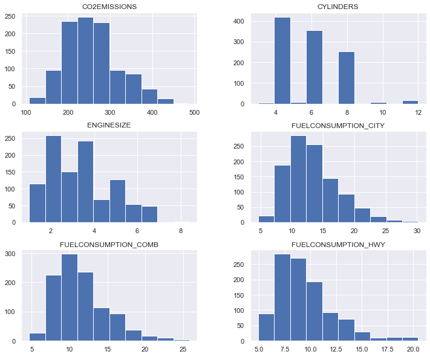

```python
# Checking feature distribution
data_new.hist();
```

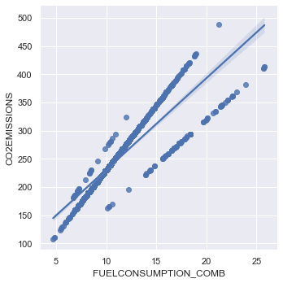

```python
# Checking linear relationship with Emissions
sns.lmplot('FUELCONSUMPTION_COMB','CO2EMISSIONS',data=data_new)
```

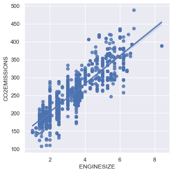

```python
# Checking linear relationship with Emissions
sns.lmplot('ENGINESIZE','CO2EMISSIONS',data=data_new)
```

```python
# Splitting the data
X = data_new['ENGINESIZE'].values
Y = data_new['CO2EMISSIONS'].values

from sklearn.model_selection import train_test_split
X_train, X_test, y_train, y_test = train_test_split(X, Y, test_size = 0.2, random_state = 0)
```

```python
X_train[0:10]
```

```
array([3.600000, 4.600000, 3.500000, 2.500000, 1.500000, 4.700000,
       8.400000, 2.000000, 2.000000, 2.400000])
```

```python
y_train[0:10]
```

```
array([290, 347, 244, 218, 170, 267, 389, 138, 218, 198], dtype=int64)
```

### *Model using sklearn*

```python
# Building Linear regression model
from sklearn.linear_model import LinearRegression

reg = LinearRegression()
reg.fit(X_train.reshape(-1, 1), y_train.reshape(-1, 1))
```

```
LinearRegression()
```

```python
# beta coefficient
reg.coef_
```

```
array([[39.248384]])
```

```python
# Intercept value
reg.intercept_
```

```
array([126.189202])
```

```python
# Score on the Test Set
reg.score(X_test.reshape(-1,1),y_test.reshape(-1,1))
```

```
0.7201153918073576
```

```python
# Prediction for the test set
y_pred = reg.predict(X_test.reshape(-1,1))
y_pred[:10]
```

```
array([[342.055315],
       [220.385324],
       [220.385324],
       [232.159839],
       [224.310162],
       [298.882093],
       [220.385324],
       [267.483385],
       [220.385324],
       [322.431123]])
```

```python
# Actuals
y_test[:10]
```

```
array([356, 209, 230, 212, 168, 292, 212, 276, 202, 334], dtype=int64)
```

```python
# residuals or Error
residuals = y_test.reshape(-1,1)-y_pred.reshape(-1,1)
residuals[:10]
```

```
array([[13.944685],
       [-11.385324],
       [9.614676],
       [-20.159839],
       [-56.310162],
       [-6.882093],
       [-8.385324],
       [8.516615],
       [-18.385324],
       [11.568877]])
```

```python
# Evaluation Metrics

from sklearn.metrics import r2_score, mean_absolute_error, mean_squared_error

print("R-squared value of predictions:",round(r2_score(y_test,y_pred),3))
print("Mean absolute error (MAE):", mean_absolute_error(y_test,y_pred))
print("Mean square error (MSE):", mean_squared_error(y_test,y_pred))
print("Root mean square error (RMSE):", np.sqrt(mean_squared_error(y_test,y_pred)))
```

```
R-squared value of predictions: 0.72
Mean absolute error (MAE): 25.56889045602356
Mean square error (MSE): 1181.528809303555
Root mean square error (RMSE): 34.37337355139229
```

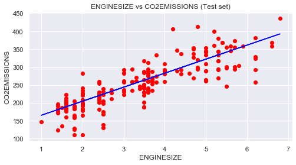

```python
# Visualising the Test set results and regression line

plt.figure(figsize = (8,4))
plt.scatter(X_test, y_test, color = 'red')
plt.plot(X_test, y_pred, color = 'blue')
plt.title('ENGINESIZE vs CO2EMISSIONS (Test set)')
plt.xlabel('ENGINESIZE')
plt.ylabel('CO2EMISSIONS')
plt.show()
```

### *Model using OLS in statsmodel*

```python
# load statsmodels for OLS
import statsmodels.api as sm
```

```python
# Splitting the data
X = data_new['ENGINESIZE'].values
Y = data_new['CO2EMISSIONS'].values
X2 = sm.add_constant(X) # adding constant to get the Intercept value

from sklearn.model_selection import train_test_split
X_train, X_test, y_train, y_test = train_test_split(X2, Y, test_size = 0.2, random_state = 0)
```

```python
# Creating model
model = sm.OLS(endog = y_train,exog = X_train)
results = model.fit()
```

```python
results.summary()
```

OLS Regression Results

| Dep. Variable: | y | R-squared: | 0.775 |
| --- | --- | --- | --- |
| Model: | OLS | Adj. R-squared: | 0.775 |
| Method: | Least Squares | F-statistic: | 2929. |
| Date: | Thu, 02 Jul 2020 | Prob (F-statistic): | 9.16e-278 |
| Time: | 22:24:22 | Log-Likelihood: | -4106.5 |
| No. Observations: | 853 | AIC: | 8217. |
| Df Residuals: | 851 | BIC: | 8227. |
| Df Model: | 1 |  |  |
| Covariance Type: | nonrobust |  |  |

|  | coef | std err | t | P>\|t\| | [0.025 | 0.975] |
| --- | --- | --- | --- | --- | --- | --- |
| const | 126.1892 | 2.634 | 47.901 | 0.000 | 121.019 | 131.360 |
| x1 | 39.2484 | 0.725 | 54.119 | 0.000 | 37.825 | 40.672 |

| Omnibus: | 23.883 | Durbin-Watson: | 2.067 |
| --- | --- | --- | --- |
| Prob(Omnibus): | 0.000 | Jarque-Bera (JB): | 36.987 |
| Skew: | 0.241 | Prob(JB): | 9.30e-09 |
| Kurtosis: | 3.899 | Cond. No. | 9.97 |

Warnings:  
[1] Standard Errors assume that the covariance matrix of the errors is correctly specified.

```python
# get paramter values
results.params
```

```
array([126.189202, 39.248384])
```

```python
# prediction
y_pred = results.predict(X_test)
y_pred[:10]
```

```
array([342.055315, 220.385324, 220.385324, 232.159839, 224.310162,
       298.882093, 220.385324, 267.483385, 220.385324, 322.431123])
```

*This summary provides quite a lot of information about the fit. The pats of the table we think are the most important are bolded in the description below.*

*The left part of the first table provides basic information about the model fit:*

| Element | Description |
| --- | --- |
| Dep. Variable | Which variable is the response in the model |
| Model | What model you are using in the fit |
| Method | How the parameters of the model were calculated |
| No. Observations | The number of observations (examples) |
| DF Residuals | Degrees of freedom of the residuals. Number of observations - number of parameters |
| DF Model | Number of parameters in the model (not including the constant term if present) |

*The right part of the first table shows the goodness of fit*

Element

Description

**R-squared**

The [coefficient of determination]. R Square is a basic matrix which tells you about that how much variance is been explained by the model. In a multivariate linear regression is that if you keep on adding new variables, the R square value will always increase irrespective of the variable significance.

**Adj. R-squared**

Adjusted R square calculates R square from only those variables whose addition in the model which are significant. So always while doing a multivariate linear regression we should look at adjusted R square instead of R square.

F-statistic

A measure how significant the fit is. The mean squared error of the model divided by the mean squared error of the residuals. What should i do with F statistic in Regression model ?

- If my F-statistic is significant that gives me extra confidence on the R² value that i have got .
- In case i get insignificant F-Statistic or if p values for F are greater that level of significance ( say 0.05 or 0.01 ) then personally i would stay away from that model since i will not be able to confidently comment on the R² values

Prob (F-statistic)

The probability that you would get the above statistic, given the null hypothesis that they are unrelated

Log-likelihood

The log of the likelihood function.

AIC

The Akaike Information Criterion. Adjusts the log-likelihood based on the number of observations and the complexity of the model.

BIC

The Bayesian Information Criterion. Similar to the AIC, but has a higher penalty for models with more parameters.

*The second table reports for each of the coefficients*

[output not shown]

Finally, there are several statistical tests to assess the distribution of the residuals

| Element | Description |
| --- | --- |
| Skewness | A measure of the symmetry of the data about the mean. Normally-distributed errors should be symmetrically distributed about the mean (equal amounts above and below the line). |
| Kurtosis | A measure of the shape of the distribution. Compares the amount of data close to the mean with those far away from the mean (in the tails). |
| Omnibus | D'Angostino's test. It provides a combined statistical test for the presence of skewness and kurtosis. |
| Prob(Omnibus) | The above statistic turned into a probability |
| Jarque-Bera | A different test of the skewness and kurtosis |
| Prob (JB) | The above statistic turned into a probability |
| Durbin-Watson | A test for the presence of autocorrelation (that the errors are not independent.) Often important in time-series analysis |
| Cond. No | A test for multicollinearity (if in a fit with multiple parameters, the parameters are related with each other). |

*T-Statistic and is associated p-values are very important metrics while checking model fitment.*

*The t-statistics tests whether there is a statistically significant relationship between the independent and dependent variable. This means whether the beta coefficient of the independent variable is significantly different from 0. So, the higher the t-value the better.*

*Whenever there is a p-value, there is always a null as well as an alternate hypothesis associated with it. The p-value helps us to test for the null hypothesis, i.e., the coefficients are equal to 0. A low p-value means we can reject the null hypothesis.*

*The statistical hypotheses are as follow:*

*Null Hypothesis (H0) – Coefficients are equal to zero.*

*Alternate Hypothesis (H1) – Coefficients are not equal to zero.*

*when the p-value < 0.05, we can safely reject the null hypothesis.*

### *Model using Scipy Stats*

```
Slope 39.125199786711704
Intercept 125.30409949535698
```

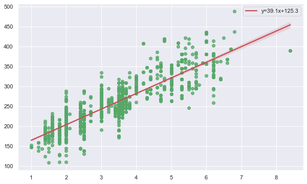

```python
# Import Stats from Scipy
from scipy import stats

sns.set(color_codes=True)

slope, intercept, r_value, p_value, std_err = stats.linregress(data_new['ENGINESIZE'], data_new['CO2EMISSIONS'])
print('Slope', slope)
print('Intercept', intercept)
f = plt.figure(figsize=(10,6))
ax = sns.regplot(x=X, y=Y,
                 scatter_kws={"color": "g"},
                line_kws={'color': 'r', 'label':"y={0:.1f}x+{1:.1f}".format(slope,intercept)})
ax.legend()
```

### *Model using Graident Descent*

```python
X2[0:10]
```

```
array([[1.000000, 2.000000],
       [1.000000, 2.400000],
       [1.000000, 1.500000],
       [1.000000, 3.500000],
       [1.000000, 3.500000],
       [1.000000, 3.500000],
       [1.000000, 3.500000],
       [1.000000, 3.700000],
       [1.000000, 3.700000],
       [1.000000, 2.400000]])
```

```python
Y[0:10]
```

```
array([196, 221, 136, 255, 244, 230, 232, 255, 267, 212], dtype=int64)
```

```python
def computeCost(x, y, theta):
    m = len(y)
    h_x = np.dot(x, theta)
    j = np.sum(np.square(h_x - y))/(2*m)
    return j
```

```python
def GradientDescent(x, y, theta, alpha, iteration):
    print('Running Gradient Descent')
    j = []
    for i in range(0,iteration+1):
        j.append(computeCost(x, y, theta))
        m = len(y)
        h_x = np.dot(x, theta)
        theta[1] = theta[1] - alpha/m *(np.sum( np.dot(x.T, (h_x) - y)))
        theta[0] = theta[0] - alpha/m *(np.sum((h_x) - y))
    return theta, j
```

```python
theta = np.zeros((2,1))

# we need to adjust thesse values
iteration = 50
alpha = 0.0001

theta, cost = GradientDescent(X2, Y, theta, alpha, iteration)
print('Theta found by Gradient Descent: slope = {} and intercept {}'.format(theta[1], theta[0]))
```

[output not shown]

## *Multiple Linear Regression*

*Multiple Linear Regression attempts to model the relationship between two or more features and a response by fitting a linear equation to observed data. The steps to perform multiple linear Regression are almost similar to that of simple linear Regression.*

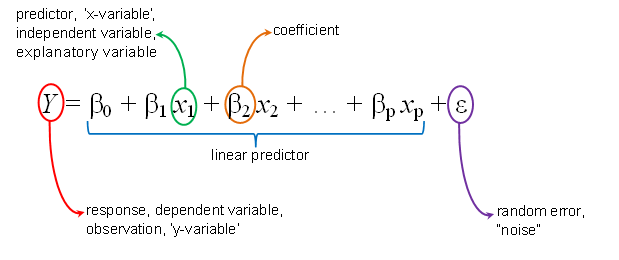

```python
# Reading dataset

data = pd.read_csv(r'C:\Users\PiyushSin\Downloads\USA_Housing.csv')
data.head()
```

|  | Avg. Area Income | Avg. Area House Age | Avg. Area Number of Rooms | Avg. Area Number of Bedrooms | Area Population | Price | Address |
| --- | --- | --- | --- | --- | --- | --- | --- |
| 0 | 79545.458574 | 5.682861 | 7.009188 | 4.09 | 23086.800503 | 1.059034e+06 | 208 Michael Ferry Apt. 674\nLaurabury, NE 3701... |
| 1 | 79248.642455 | 6.002900 | 6.730821 | 3.09 | 40173.072174 | 1.505891e+06 | 188 Johnson Views Suite 079\nLake Kathleen, CA... |
| 2 | 61287.067179 | 5.865890 | 8.512727 | 5.13 | 36882.159400 | 1.058988e+06 | 9127 Elizabeth Stravenue\nDanieltown, WI 06482... |
| 3 | 63345.240046 | 7.188236 | 5.586729 | 3.26 | 34310.242831 | 1.260617e+06 | USS Barnett\nFPO AP 44820 |
| 4 | 59982.197226 | 5.040555 | 7.839388 | 4.23 | 26354.109472 | 6.309435e+05 | USNS Raymond\nFPO AE 09386 |

```python
data.info()
```

```
<class 'pandas.core.frame.DataFrame'>
RangeIndex: 5000 entries, 0 to 4999
Data columns (total 7 columns):
Avg. Area Income                5000 non-null float64
Avg. Area House Age             5000 non-null float64
Avg. Area Number of Rooms       5000 non-null float64
Avg. Area Number of Bedrooms    5000 non-null float64
Area Population                 5000 non-null float64
Price                           5000 non-null float64
Address                         5000 non-null object
dtypes: float64(6), object(1)
memory usage: 273.6+ KB
```

```python
data.describe()
```

|  | Avg. Area Income | Avg. Area House Age | Avg. Area Number of Rooms | Avg. Area Number of Bedrooms | Area Population | Price |
| --- | --- | --- | --- | --- | --- | --- |
| count | 5000.000000 | 5000.000000 | 5000.000000 | 5000.000000 | 5000.000000 | 5.000000e+03 |
| mean | 68583.108984 | 5.977222 | 6.987792 | 3.981330 | 36163.516039 | 1.232073e+06 |
| std | 10657.991214 | 0.991456 | 1.005833 | 1.234137 | 9925.650114 | 3.531176e+05 |
| min | 17796.631190 | 2.644304 | 3.236194 | 2.000000 | 172.610686 | 1.593866e+04 |
| 25% | 61480.562388 | 5.322283 | 6.299250 | 3.140000 | 29403.928702 | 9.975771e+05 |
| 50% | 68804.286404 | 5.970429 | 7.002902 | 4.050000 | 36199.406689 | 1.232669e+06 |
| 75% | 75783.338666 | 6.650808 | 7.665871 | 4.490000 | 42861.290769 | 1.471210e+06 |
| max | 107701.748378 | 9.519088 | 10.759588 | 6.500000 | 69621.713378 | 2.469066e+06 |

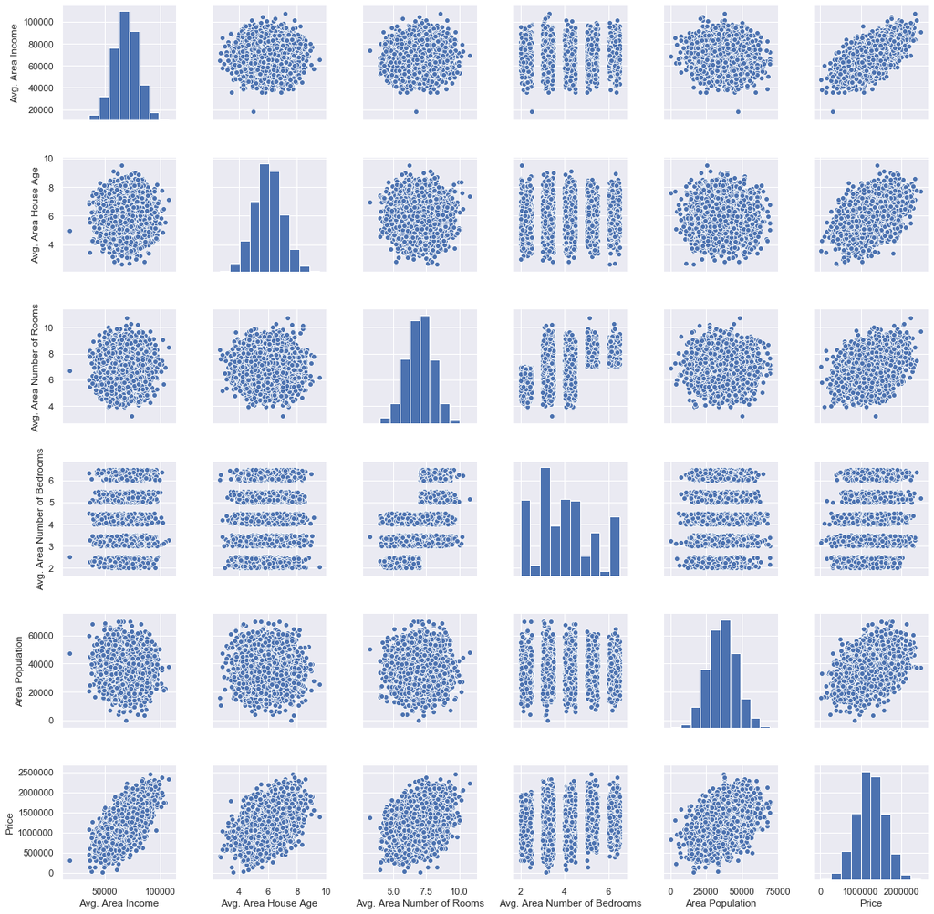

```python
sns.pairplot(data)
```

```python
data.columns
```

```
Index(['Avg. Area Income', 'Avg. Area House Age', 'Avg. Area Number of Rooms',
       'Avg. Area Number of Bedrooms', 'Area Population', 'Price', 'Address'],
      dtype='object')
```

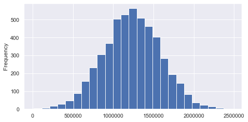

```python
data['Price'].plot.hist(bins=25,figsize=(8,4))
```

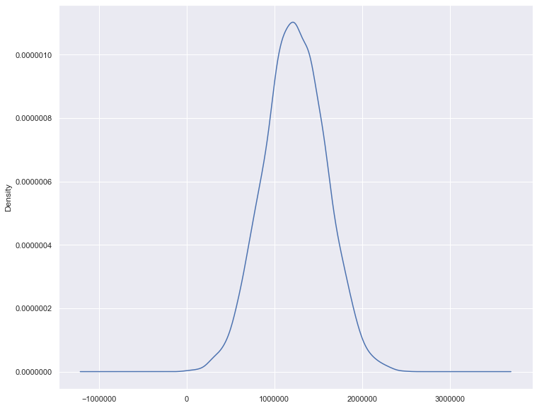

```python
data['Price'].plot.density()
```

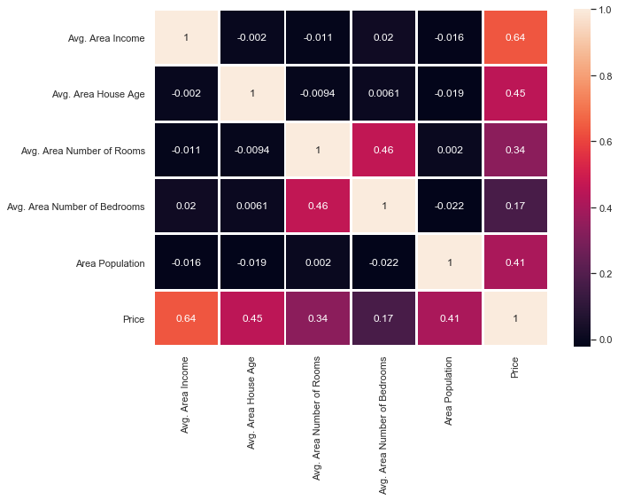

```python
# correlation
plt.figure(figsize=(10,7))
sns.heatmap(data.corr(),annot=True,linewidths=2)
```

```python
X = data[['Avg. Area Income', 'Avg. Area House Age', 'Avg. Area Number of Rooms',
       'Avg. Area Number of Bedrooms', 'Area Population']]
Y = data['Price']
```

```python
print("Feature set size:",X.shape)
print("Variable set size:",Y.shape)
```

```
Feature set size: (5000, 5)
Variable set size: (5000,)
```

```python
X_train, X_test, y_train, y_test = train_test_split(X, Y, test_size=0.3, random_state=123)
```

```python
X_train.head()
```

|  | Avg. Area Income | Avg. Area House Age | Avg. Area Number of Rooms | Avg. Area Number of Bedrooms | Area Population |
| --- | --- | --- | --- | --- | --- |
| 4036 | 74279.926228 | 6.929481 | 7.369607 | 5.40 | 26947.152504 |
| 2883 | 56957.835209 | 5.969854 | 5.935709 | 2.05 | 29498.964187 |
| 4162 | 77453.479788 | 5.909818 | 7.640186 | 3.02 | 53100.278674 |
| 4640 | 77906.185182 | 6.537044 | 9.458466 | 3.08 | 31399.756830 |
| 2430 | 62472.158580 | 6.704512 | 7.665173 | 6.48 | 37618.676554 |

```python
print("Training feature set size:",X_train.shape)
print("Test feature set size:",X_test.shape)
print("Training variable set size:",y_train.shape)
print("Test variable set size:",y_test.shape)
```

```
Training feature set size: (3500, 5)
Test feature set size: (1500, 5)
Training variable set size: (3500,)
Test variable set size: (1500,)
```

### *Model using sklearn*

```python
lm = LinearRegression()
lm.fit(X_train,y_train)
```

```
LinearRegression()
```

```python
print("The intercept term of the linear model:", lm.intercept_)
```

```
The intercept term of the linear model: -2631028.901746378
```

```python
print("The coefficients of the linear model:", lm.coef_)
```

```
The coefficients of the linear model: [21.597602 165201.104954 119061.463868 3212.585606 15.228121]
```

```python
pd.DataFrame(data=lm.coef_, index=X_train.columns, columns=["Coefficients"])
```

|  | Coefficients |
| --- | --- |
| Avg. Area Income | 21.597602 |
| Avg. Area House Age | 165201.104954 |
| Avg. Area Number of Rooms | 119061.463868 |
| Avg. Area Number of Bedrooms | 3212.585606 |
| Area Population | 15.228121 |

```python
y_pred = lm.predict(X_test)
y_pred
```

```
array([791123.506012, 697223.199090, 1414478.551925, ..., 1646511.061610,
       592560.955015, 979949.890083])
```

```python
residuals = y_test-y_pred
residuals.head()
```

```
2648      9022.720049
2456     10121.863342
4557   -196214.531062
4884     33224.548599
92     -194659.145897
Name: Price, dtype: float64
```

### *Model using OLS in statsmodel*

```python
model = sm.OLS(endog = y_train,exog = X_train)
results = model.fit()
```

```python
results.summary()
```

OLS Regression Results

| Dep. Variable: | Price | R-squared (uncentered): | 0.965 |
| --- | --- | --- | --- |
| Model: | OLS | Adj. R-squared (uncentered): | 0.965 |
| Method: | Least Squares | F-statistic: | 1.936e+04 |
| Date: | Thu, 02 Jul 2020 | Prob (F-statistic): | 0.00 |
| Time: | 22:25:07 | Log-Likelihood: | -48320. |
| No. Observations: | 3500 | AIC: | 9.665e+04 |
| Df Residuals: | 3495 | BIC: | 9.668e+04 |
| Df Model: | 5 |  |  |
| Covariance Type: | nonrobust |  |  |

|  | coef | std err | t | P>\|t\| | [0.025 | 0.975] |
| --- | --- | --- | --- | --- | --- | --- |
| Avg. Area Income | 10.2152 | 0.318 | 32.107 | 0.000 | 9.591 | 10.839 |
| Avg. Area House Age | 5.041e+04 | 3505.959 | 14.377 | 0.000 | 4.35e+04 | 5.73e+04 |
| Avg. Area Number of Rooms | -8723.1161 | 3874.857 | -2.251 | 0.024 | -1.63e+04 | -1125.905 |
| Avg. Area Number of Bedrooms | 4307.3289 | 3691.852 | 1.167 | 0.243 | -2931.075 | 1.15e+04 |
| Area Population | 8.1329 | 0.383 | 21.223 | 0.000 | 7.382 | 8.884 |

| Omnibus: | 0.414 | Durbin-Watson: | 2.006 |
| --- | --- | --- | --- |
| Prob(Omnibus): | 0.813 | Jarque-Bera (JB): | 0.464 |
| Skew: | -0.015 | Prob(JB): | 0.793 |
| Kurtosis: | 2.952 | Cond. No. | 9.31e+04 |

Warnings:  
[1] Standard Errors assume that the covariance matrix of the errors is correctly specified.  
[2] The condition number is large, 9.31e+04. This might indicate that there are  
strong multicollinearity or other numerical problems.

### *Feature Selection*

*Read More: [Feature Selection](https://github.com/PIYUSHSINGLA/Feature-Selection-and-Dimensionality-Reduction)*

```python
from sklearn.ensemble import ExtraTreesRegressor

# feature extraction
model = ExtraTreesRegressor(n_estimators=10)
model.fit(X, Y)
print(model.feature_importances_)
```

```
[0.429568 0.228039 0.129752 0.024241 0.188399]
```

## *Cross Validation*

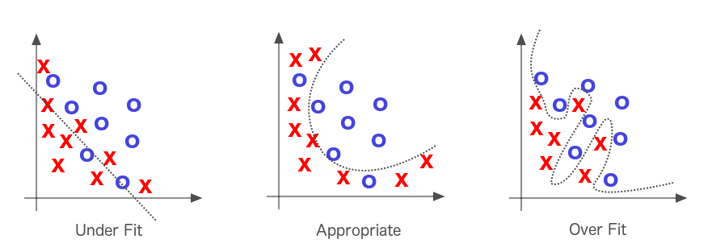

### *Underfitting and Overfitting*

*While we fit a model, we try to find the optimised, best-fit line, which can describe the impact of the change in the independent variable on the change in the dependent variable by keeping the error term minimum. While fitting the model, there can be 2 events which will lead to the bad performance of the model. These events are*

- *Underfitting*
- *Overfitting*

*Underfitting*

*Underfitting is the condition where the model could not fit the data well enough. The under-fitted model leads to low accuracy of the model. Therefore, the model is unable to capture the relationship, trend or pattern in the training data. Underfitting of the model could be avoided by using more data, or by optimising the parameters of the model.*

*Overfitting*

*Overfitting is the opposite case of underfitting, i.e., when the model predicts very well on training data and is not able to predict well on test data or validation data. The main reason for overfitting could be that the model is memorising the training data and is unable to generalise it on test/unseen dataset. Overfitting can be reduced by doing feature selection or by using regularisation techniques.*

### *K-Fold Validation*

*K-Fold CV is where a given data set is split into a K number of sections/folds where each fold is used as a testing set at some point. Lets take the scenario of 5-Fold cross validation(K=5). Here, the data set is split into 5 folds. In the first iteration, the first fold is used to test the model and the rest are used to train the model. In the second iteration, 2nd fold is used as the testing set while the rest serve as the training set. This process is repeated until each fold of the 5 folds have been used as the testing set.*

- *K-Fold Cross Validation*
- *Stratified K-fold Cross Validation*
- *Leave One Out Cross Validation*

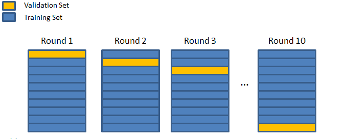

```python
from sklearn.model_selection import KFold, cross_val_score
from sklearn.metrics import make_scorer, r2_score

def test_model(model, X_train=X_train, y_train=y_train):
    cv = KFold(n_splits = 3, shuffle=True, random_state = 45)
    r2 = make_scorer(r2_score)
    r2_val_score = cross_val_score(model, X_train, y_train, cv=cv, scoring = r2)
    score = [round(r2_val_score.mean()*100,2)]
    return score
```

```python
test_model(lm)
```

```
[91.68]
```

## *Evaluation Metrics*

### *R-Squared*

*R-squared is a statistical measure of how close the data are to the fitted regression line. It is also known as the **coefficient of determination**, or the coefficient of multiple determination for multiple regression.*

*The definition of R-squared is fairly straight-forward; it is the percentage of the response variable variation that is explained by a linear model. Or:*

*R-squared = Explained variation / Total variation*

*R-squared is always between 0 and 100%:*

*0% indicates that the model explains none of the variability of the response data around its mean. 100% indicates that the model explains all the variability of the response data around its mean. In general, the higher the R-squared, the better the model fits your data.*

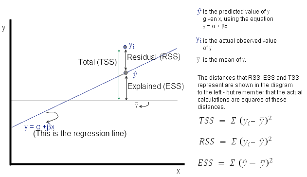

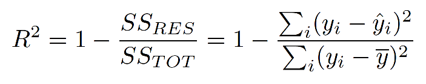

### *Mean Absolute Error*

*MAE measures the average magnitude of the errors in a set of predictions, without considering their direction. It is the average over the test sample of the absolute differences between prediction and actual observation where all individual differences have equal weight.*

*MAPE*

*The mean absolute percentage error (MAPE) is the percentage equivalent of MAE. The equation looks just like that of MAE, but with adjustments to convert everything into percentages.*

### *Mean Squared Error*

*It is mean of square of errors.*

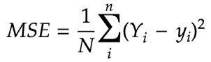

### *Root Mean Squared Error*

*RMSE is the standard deviation of the errors which occur when a prediction is made on a dataset. This is the same as MSE (Mean Squared Error) but the root of the value is considered while determining the accuracy of the model.*

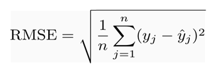

*Similarity in MAE and RMSE:*

*Both MAE and RMSE express average model prediction error in units of the variable of interest. Both metrics can range from 0 to ∞ and are indifferent to the direction of errors. They are negatively-oriented scores, which means lower values are better.*

*Differences:*

*Taking the square root of the average squared errors has some interesting implications for RMSE. Since the errors are squared before they are averaged, the RMSE gives a relatively high weight to large errors. This means the RMSE should be more useful when large errors are particularly undesirable.*